# Reddit Data Analysis

# 4. N-grams

N-grams are used to analyze words in context. When we say (1) “We need to check the details.” and (2) “Can we pay it with a check?”, the word check are used as a verb and as a noun. We know what ‘check’ means in a sentence based on other words in the sentence, particularly words that are before and after the word ‘check.’ For example, if the word ‘check’ is used after ‘to’, we can infer that it is used as a verb. You can test bi-grams (2 words), tri-grams (3 words), and so on.

For example, “The result of separating bigrams is helpful for exploratory analyses of the text.” becomes **paired_words**  
1 the result  
2 result of  
3 of separating  
4 separating bigrams  
5 bigrams is  
6 is helpful  
7 helpful for  
8 for exploratory  
9 exploratory analyses  
10 analyses of  
11 of the  
12 the text

```r
# Get ngrams. You may try playing around with the value of n, n=3 , n=4
words_ngram <- threads_2 %>%
  mutate(text = str_replace_all(text, replace_reg, "")) %>%
  select(text) %>%
  unnest_tokens(output = paired_words,
                input = text,
                token = "ngrams",
                n = 2)
```

```r
# Show ngrams with sorted values
words_ngram %>%
  count(paired_words, sort = TRUE) %>%
  head(20) %>%
  knitr::kable()
```

| paired_words | n |
| --- | --- |
| NA | 589 |
| and i | 82 |
| i was | 71 |
| on the | 69 |
| in the | 68 |
| i m | 63 |
| of the | 58 |
| to the | 57 |
| the bike | 56 |
| it s | 52 |
| my bike | 50 |
| to get | 47 |
| it was | 44 |
| but i | 43 |
| a bike | 42 |
| i have | 42 |
| for a | 40 |
| for the | 40 |
| in a | 38 |
| i am | 37 |

Here we see the ngrams contain stop words such as * a, to, etc.* Next we will try to obtain ngrams occurring without stop words. We will use the *separate* function of the *tidyr* library to obtain the paired words in two columns i.e. *word 1* and *word 2*. Subsequently we filter out columns containing stop words using the *filter function*

```r
#separate the paired words into two columns
words_ngram_pair <- words_ngram %>%
  separate(paired_words, c("word1", "word2"), sep = " ")

# filter rows where there are stop words under word 1 column and word 2 column
words_ngram_pair_filtered <- words_ngram_pair %>%
  # drop stop words
  filter(!word1 %in% stop_words$word & !word2 %in% stop_words$word) %>%
  # drop non-alphabet-only strings
  filter(str_detect(word1, "[a-z]") & str_detect(word2, "[a-z]"))

# Filter out words that are not encoded in ASCII
# To see what's ASCII, google 'ASCII table'
library(stringi)
words_ngram_pair_filtered %<>%
  filter(stri_enc_isascii(word1) & stri_enc_isascii(word2))

# Sort the new bi-gram (n=2) counts:
words_counts <- words_ngram_pair_filtered %>%
  count(word1, word2) %>%
  arrange(desc(n))

head(words_counts, 20) %>%
  knitr::kable()
```

| word1 | word2 | n |
| --- | --- | --- |
| road | bike | 13 |
| bike | shop | 11 |
| months | ago | 10 |
| na | na | 10 |
| bike | ride | 6 |
| bottom | bracket | 6 |
| local | bike | 6 |
| bike | rack | 5 |
| carbon | fiber | 5 |
| cycling | shoes | 5 |
| parking | lot | 5 |
| seat | post | 5 |
| bike | lane | 4 |
| disc | wheel | 4 |
| fillet | brazing | 4 |
| mental | health | 4 |
| mountain | biking | 4 |
| quick | release | 4 |
| rainy | season | 4 |
| silver | fillet | 4 |

By using the igraph and ggraph library we can visualize the words occurring in pairs.

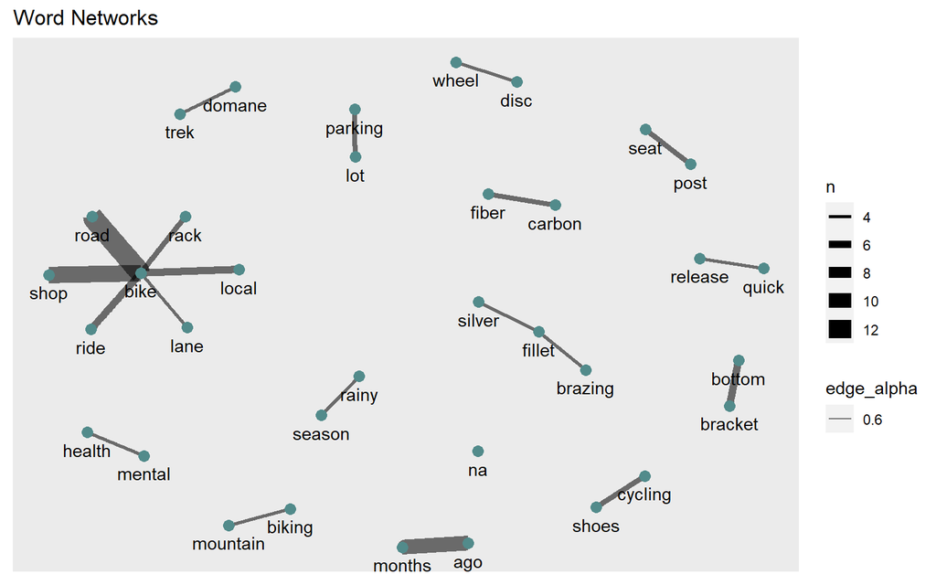

```r
# plot word network
words_counts %>%
  filter(n >= 4) %>%
  graph_from_data_frame() %>% # convert to graph
  ggraph(layout = "fr") +
  geom_edge_link(aes(edge_alpha = .6, edge_width = n)) +
  geom_node_point(color = "darkslategray4", size = 3) +
  geom_node_text(aes(label = name), vjust = 1.8) +
  labs(title = "Word Networks",
       x = "", y = "")
```